# What Does a Whiter Chicago Look Like?

Cory Rand

April 14, 2019

[figure not shown]

```r
demo_graph_data <- master %>%
  select(REGION, YEAR, nhwht, nhblk, asian, hisp) %>%
  distinct() %>%
  group_by(YEAR) %>%
  summarize(White = sum(nhwht, na.rm = T),
            Black = sum(nhblk, na.rm = T),
            Asian = sum(asian, na.rm = T),
            Hispanic = sum(hisp, na.rm = T)) %>%
  filter(White != 0, YEAR > 1970) %>%
  gather(key = "Race", value = "Pop", -c(YEAR))

demo_graph_data$Pop[demo_graph_data$Pop == 0] <- NA

  ggplot(demo_graph_data, aes(x = YEAR, y = Pop, col = Race)) +
  scale_color_manual(values= c("#D60000", "#FF5416","#E49DE8", "#00B28F")) +
  scale_y_continuous(labels = comma) +
  geom_point(size = 2, alpha = 0.7) +
  geom_smooth(linetype = "dashed", size = 0.5, alpha = 0.5) +
  labs(
  title="Chicago's White Population Up, Minorities Down or Steady",
  subtitle="Populations by Race: 1970-2017 (lines are imputed)",
  caption="Data from American Community Survey",
  x="Year",
  y="Population"
  ) +
  # geom_rect(xmin = 1999, xmax = 2018,
  #           ymin = 100000, ymax = 1400000,
  #           alpha = 0, color = "grey", size = 1) +
  annotate("text", label="White", x=1980, y=1370000, size=3.5, color = "#00B28F", family="Segoe UI Semibold") +
  annotate("text", label="Black", x=1980, y=1075000, size=3.5, color = "#FF5416", family="Segoe UI Semibold") +
  annotate("text", label="Asian", x=1980, y=195000, size=3.5, color = "#D60000", family="Segoe UI Semibold") +
  annotate("text", label="Hispanic", x=1980.5, y=501000, size=3.5, color = "#E49DE8", family="Segoe UI Semibold") +
    theme_classic() +
  theme_custom +
      theme(legend.position="none")
```

Since 2000, most neighborhoods have become less black and more white. The plot below shows the percentage change in each neighborhood’s black and white populations between 2000 and 2017, represented as coordinates on a graph. The majority of Chicago’s neighborhoods cluster on the lower right quadrant, signaling an increase in white resident percentage (X axis) and a decrease in black resident percentage (Y axis).

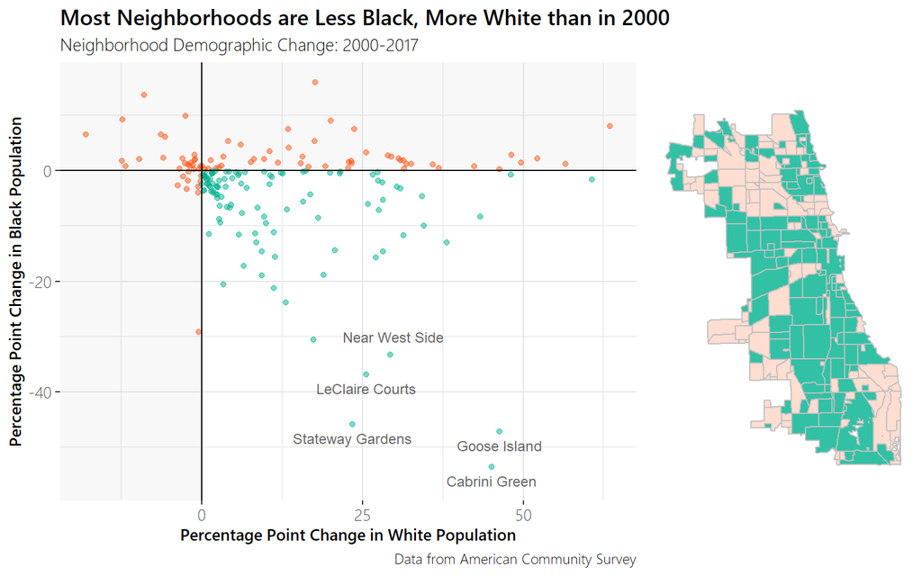

```r
plot_data <- neighborhood_master_wide %>%
    mutate(pblack_2000_2017 = (`2017_pblack` - `2000_pblack`)* 100,
           pwhite_2000_2017 = (`2017_pwhite` - `2000_pwhite`)* 100) %>%
  subset(subset = RegionID != "403159" & !is.na(pwhite_2000_2017), select=c(long, lat, group, RegionID, pwhite_2000_2017, pblack_2000_2017)) %>%
  left_join(zillow_shp[, c("RegionID", "Name")]) %>%
  distinct(RegionID, .keep_all = T) %>%
  mutate(highlight = pwhite_2000_2017 > 0 & pblack_2000_2017 < 0)

p1 <- plot_data %>%
ggplot(aes(x = pwhite_2000_2017, y = pblack_2000_2017, label = Name, col = highlight)) +
 annotate("rect", xmin = -Inf, xmax = 0, ymin = -Inf, ymax = Inf, fill= "grey", alpha = 0.1)  +
 annotate("rect", xmin = 0, xmax = Inf, ymin = 0, ymax = Inf, fill= "grey", alpha = 0.1)  +
  geom_jitter(alpha = 0.5) +
  geom_hline(yintercept = 0) +
  geom_vline(xintercept = 0) +
  geom_text(data = plot_data[which(plot_data$pwhite_2000_2017 > 20 & plot_data$pblack_2000_2017 < -35),],
            aes(x = pwhite_2000_2017, y = pblack_2000_2017, label = Name),
            size = 3.2,
            nudge_y = -2.5,
            family="Segoe UI Bold",
            color = "black",
            alpha = .6) +
  annotate("text", label="Near West Side", x=29.8, y=-30, alpha = .6, size=3.2, family="Segoe UI Bold") +
  scale_color_manual(values = c("#FF5416", "#00B28F")) +
       labs(x = "Percentage Point Change in White Population",
          y = "Percentage Point Change in Black Population",
          title = "Most Neighborhoods are Less Black, More White than in 2000",
          subtitle = "Neighborhood Demographic Change: 2000-2017",
          caption = "Data from American Community Survey") +
    theme_classic() +
  theme_custom +
   theme(axis.line = element_blank()) +
    theme(legend.position="none")

temp_data <- neighborhood_master_wide %>%
    mutate(pblack_2000_2017 = `2017_pblack` - `2000_pblack`,
           pwhite_2000_2017 = `2017_pwhite` - `2000_pwhite`) %>%
  subset(subset = RegionID != "403159" & !is.na(pwhite_2000_2017), select=c(long, lat, group, RegionID, pwhite_2000_2017, pblack_2000_2017)) %>%
  left_join(zillow_shp[, c("RegionID", "Name")]) %>%
  mutate(highlight = pwhite_2000_2017 > 0 & pblack_2000_2017 < 0)

highlight <- temp_data$RegionID[temp_data$highlight == TRUE]

p2 <- ggplot() +
    geom_sf(data = zillow_shp[(zillow_shp$RegionID %in% highlight) & zillow_shp$RegionID != "403159",],
            fill = "#00B28F",
            alpha = .8,
            color = "#C0C0C0") +
    geom_sf(data = zillow_shp[!(zillow_shp$RegionID %in% highlight) & zillow_shp$RegionID != "403159",],
            fill = "#FF5416",
            alpha = .2,
            color = "#C0C0C0") +
    theme_minimal() +
    coord_sf(datum=NA) +
    theme(axis.line = element_blank(),
    axis.text.x = element_blank(),
    axis.text.y = element_blank(),
    axis.ticks = element_blank(),
    axis.title.x = element_blank(),
    axis.title.y = element_blank(),
    panel.grid.major = element_blank(),
    panel.grid.minor = element_blank()) +
    theme(legend.position="none")

rm(temp_data)
grid.newpage()
page.layout <- grid.layout(nrow = 1, ncol = 2, widths=c(.7, .3))
pushViewport(viewport(layout = page.layout))
print(p1, vp=viewport(layout.pos.row = 1, layout.pos.col = 1))
print(p2, vp=viewport(layout.pos.row = 1, layout.pos.col = 2))
```

Alongside this demographic shift is a trend of economic divergence. Economic activity and house values have skyrocketed in some neighborhoods, while others have faced deterioration and disinvestment. Using home value index data from Zillow, I show in the plot below how four different neighborhoods, once similar by home value rankings relative to all Chicago neighborhoods, have sharply diverged since 1995.

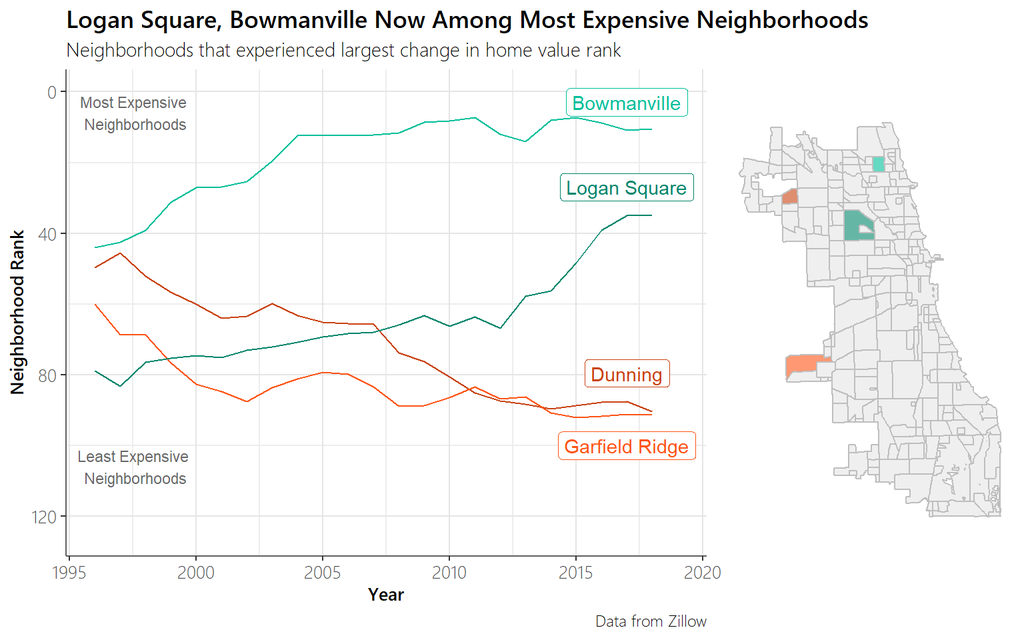

```r
master_wide_filt <- master_wide[which(!is.na(master_wide$change_rank)),]
up_neigh <- master_wide_filt$REGION[order(master_wide_filt$change_rank, decreasing = T)] %>% head(2)
down_neigh <- master_wide_filt$REGION[order(master_wide_filt$change_rank, decreasing = T)] %>% tail(2)
changing_neigh <- append(up_neigh, down_neigh)
losing_neigh <- master_wide_filt$REGION[which(master_wide_filt$change_rank < 0)]
rm(master_wide_filt)

plot_data <- master %>%
                filter(REGION %in% changing_neigh, YEAR > 1995)


p1 <- ggplot(data = plot_data, aes(x = YEAR, y = mean_rank,
                             col = factor(REGION))) +
  geom_line(aes(label = RegionName)) +
          labs(
          title="Logan Square, Bowmanville Now Among Most Expensive Neighborhoods",
          subtitle="Neighborhoods that experienced largest change in home value rank",
          caption="Data from Zillow",
          x="Year",
          y="Neighborhood Rank",
          col = NULL
          ) +
  geom_label(data = plot_data[plot_data$YEAR == 2017 &
                                plot_data$RegionName != "Garfield Ridge",],
             aes(x = YEAR, y = mean_rank,
                 col = factor(REGION),
                 label = RegionName),
             position = position_nudge(y = 8)) +
          theme_classic() +
  guides(col = FALSE) +
   scale_color_manual(values = c("#C94211", "#FF5416", "#00856B", "#00BF9A")) +
          scale_y_reverse(limits = c(125,0)) +
  annotate("label", label="Garfield Ridge", x=2017, y=100, col = "#FF5416", family="Segoe UI Bold") +
   annotate("text", label="Most Expensive \nNeighborhoods",
            x=1997.6, y=5.8, alpha = .6, family="Segoe UI Bold", size = 3) +
 annotate("text", label="Least Expensive \nNeighborhoods",
          x=1997.6, y=106, alpha = .6, family="Segoe UI Bold", size = 3) +
            theme_custom

p2 <- ggplot() +
    geom_sf(data = zillow_shp[!(zillow_shp$RegionID %in% changing_neigh) & zillow_shp$RegionID != "403159",],
            col = "grey", alpha = .6) +
    geom_sf(data = zillow_shp[zillow_shp$RegionID %in% changing_neigh,],
            aes(fill = factor(RegionID)),
            col = "grey", alpha = .6) +
    scale_fill_manual(values = c("#C94211", "#FF5416", "#00856B", "#00BF9A")) +
    theme_minimal() +
    guides(fill = FALSE) +
    coord_sf(datum=NA) +
    theme(axis.line = element_blank(),
    axis.text.x = element_blank(),
    axis.text.y = element_blank(),
    axis.ticks = element_blank(),
    axis.title.x = element_blank(),
    axis.title.y = element_blank(),
    panel.grid.major = element_blank(),
    panel.grid.minor = element_blank())

rm(plot_data)

grid.newpage()
page.layout <- grid.layout(nrow = 1, ncol = 2, widths=c(.7, .3))
pushViewport(viewport(layout = page.layout))
print(p1, vp=viewport(layout.pos.row = 1, layout.pos.col = 1))
print(p2, vp=viewport(layout.pos.row = 1, layout.pos.col = 2))
```

An additional proxy for neighborhood economic health is residential construction permits. A vibrant neighborhood with high land values may have both residential construction and demolition, as housing stock is torn down and replaced for new residents. Less in-demand neighborhoods may see little to no new construction, and perhaps demolition of vacant or blighted homes. The plot below shows building permits for new residential construction and demolition in Chicago, between 2006 and 2018. The North and Near-West neighborhoods show churn in housing stock, while South and West neighborhoods primarily experience demolition.

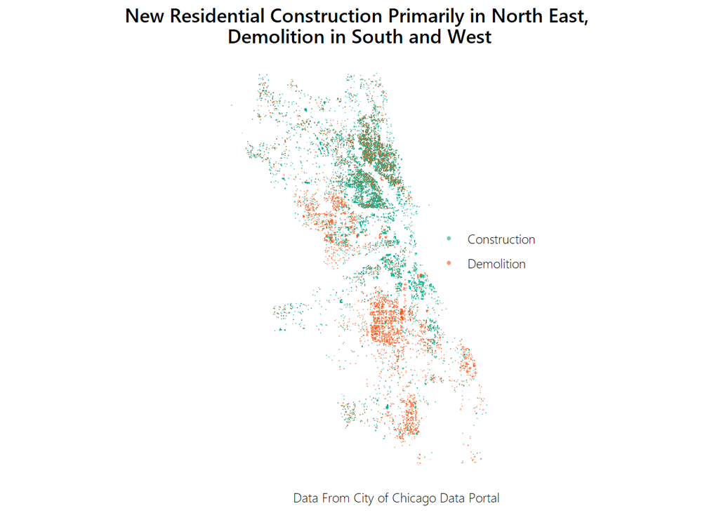

```r
 permits_filt <- st_join(permits_filt, zillow_shp %>% select, join = st_within)

 permits_res <- permits_filt %>%
   filter(YEAR > 2005, YEAR < 2019, RESIDENTIAL == 1,
          SFR==1 | MULTI ==1,
          BUILD ==1 | WRECK ==1,
          REGION != "403159")

 mat <- list(matrix(c(-87, 41,
                      -87.86, 41,
                      -87.86, 43,
                      -87, 43,
                      -87, 41
                      ),
               ncol = 2,
               byrow = TRUE))
 box <- st_polygon(mat)
 box <- st_geometry(box)
 box <- st_set_crs(box, st_crs(chicago_border))
 chicago_crop <- st_intersection(chicago_border, box)
 permits_res <- st_intersection(permits_res, chicago_border)
 neighborhood_crop <- st_intersection(zillow_shp, box)

 ggplot() +
     geom_point(data = permits_res,
                aes(x = LONGITUDE, y = LATITUDE, col = WRECK),
                size = 1.5,
                alpha =.5,
                shape = ".") +
     scale_color_manual(values = c("#00B28F","#FF5416"),
                        labels = c("Construction", "Demolition")) +
   theme_classic() +
   coord_sf(datum=NA) +
   labs(x = NULL,
         y = NULL,
         title = "New Residential Construction Primarily in North East, \nDemolition in South and West",
         #subtitle = "Building Permits for Residential Construction and Demolition: 2006 - 2018",
         caption = "Data From City of Chicago Data Portal",
         col = NULL) +
     theme_custom +
     theme(axis.line = element_blank(),
     axis.text.x = element_blank(),
     axis.text.y = element_blank(),
     axis.ticks = element_blank(),
     axis.title.x = element_blank(),
     axis.title.y = element_blank(),
     panel.grid.major = element_blank(),
     panel.grid.minor = element_blank(),
     plot.title = element_text(hjust = .5),
     legend.position = c(.95, .55))  +
     guides(color = guide_legend(override.aes = list(size = 1, shape = 16, alpha = .6)))
```

The final plot shows residential construction and demolition permit frequency over time, split into multi-family vs single-family categories. Annual permit rates drop sharply during the recession years, and although demolition numbers soon increase above pre-recession levels, construction numbers do not. We also see across time, most demolitions are of single-family homes.

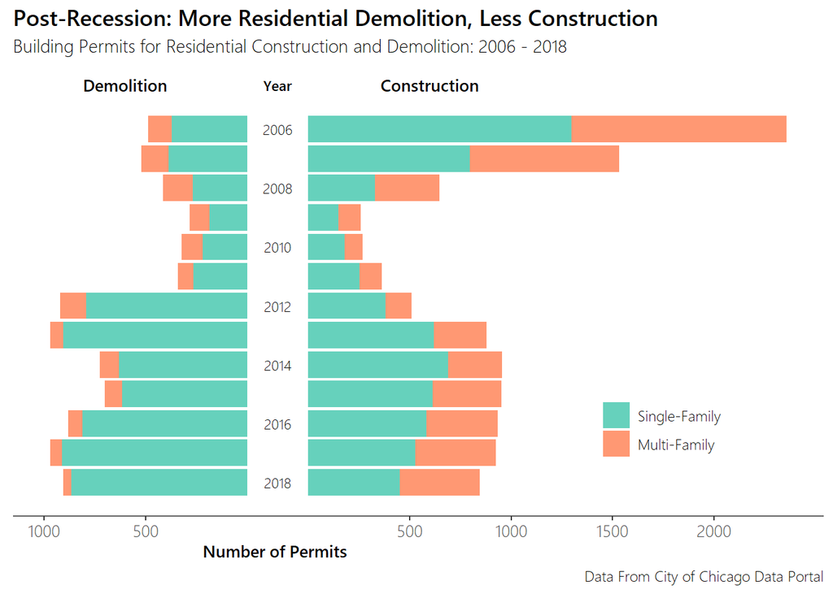

```r
 YEAR <- rep(seq(2006, 2018), 2)
 SFR <- rep(NA, 26)
 BUILD <- c(rep(TRUE, 13), rep(FALSE, 13))
 count <- rep(150, 26)
 temp <- data.frame(YEAR, SFR, BUILD, count)

 test<- permits_res %>%
   group_by(YEAR, SFR, BUILD) %>%
   summarize(count = n()) %>%
   bind_rows(temp) %>%
  mutate(count = ifelse(BUILD ==1, count, -count))

 test$geometry <- NULL

  ggplot(test, aes(x=YEAR, y=count, fill=SFR)) +
   geom_bar(stat="identity", alpha = 0.6) +
   coord_flip() +
   scale_x_reverse() +
   theme_classic() +
   scale_fill_manual(breaks = c("TRUE", "FALSE", "NA"),
                     values = c("#FF5416", "#00B28F"),
                     labels = c("Single-Family", "Multi-Family", "")) +
   #scale_x_continuous(breaks = c(2006:2018)) +
   scale_y_continuous(breaks = c(-1150, -650, 650, 1150, 1650, 2150),
                      labels = c("1000", "500", "500", "1000",
                                 "1500", "2000")) +
     labs(y = "Number of Permits",
         title = "Post-Recession: More Residential Demolition, Less Construction",
         subtitle = "Building Permits for Residential Construction and Demolition: 2006 - 2018",
         caption = "Data From City of Chicago Data Portal",
         fill = NULL) +
      annotate("text", label="Demolition", x=2004.5, y=-750, size=3.5, family="Segoe UI Semibold") +
      annotate("text", label="Construction", x=2004.5, y=750, size=3.5, family="Segoe UI Semibold") +
      annotate("text", label="Year", x=2004.5, y=0, size=3, family="Segoe UI Semibold") +
         annotate("text", label="2006", x=2006, y=0, size=3, family="Segoe UI Light") +
         annotate("text", label="2008", x=2008, y=0, size=3, family="Segoe UI Light") +
         annotate("text", label="2010", x=2010, y=0, size=3, family="Segoe UI Light") +
         annotate("text", label="2012", x=2012, y=0, size=3, family="Segoe UI Light") +
         annotate("text", label="2014", x=2014, y=0, size=3, family="Segoe UI Light") +
         annotate("text", label="2016", x=2016, y=0, size=3, family="Segoe UI Light") +
         annotate("text", label="2018", x=2018, y=0, size=3, family="Segoe UI Light") +
        theme_custom +
     theme(axis.line.y = element_blank(),
           axis.ticks.y = element_blank(),
           axis.text.y = element_blank(),
           axis.title.y = element_blank(),
           axis.title.x = element_text(hjust = 0.285),
           panel.grid.major = element_blank(),
           panel.grid.minor = element_blank(),
           legend.position = c(.8, .2))
```